# homework 3

Ekrem Barış Kuyucu

06 01 2021

## Introduction

We want to observe if there are any relationship between second hand house sales and the selected parameters interest rates, exchange rates and consumer confidence index. So we collect some data between years 2015 and 2020. I thought that exchange rates and interest rates have more effect on second hand house sales than consumer confidence index by looking their values. By building a model with second hand house sales and the other parameters, by finding a good p value and multiple R-squared value, we will try to predict next month’s(December 2020) value.

```r
library(data.table,quietly = TRUE,warn.conflicts = FALSE)
library(ggplot2,quietly = TRUE,warn.conflicts = FALSE)
library(lubridate,quietly = TRUE,warn.conflicts = FALSE)
library(zoo,quietly = TRUE,warn.conflicts = FALSE)
```

We read our data with fread function.

```r
secondhandsales<-fread("D:/Boğaziçi/İe360/data/hw3/second-hand-sales.csv",drop="V3")
interestrates<-fread("D:/Boğaziçi/İe360/data/hw3/interest-rates.csv",drop="V3")
exchangerates<-fread("D:/Boğaziçi/İe360/data/hw3/exchange-rates.csv",drop="V3")
consumerconfidenceindex<-fread("D:/Boğaziçi/İe360/data/hw3/consumer-confidence-index.csv",drop="V3")
```

We have to convert date values to date because they were char values. Also we need to add the values on interest rates, exchange rates and consumer confidence index to our main data set second hand house sales, so we take the second columns of interest rates, exchange rates and consumer confidence index and add them to second hand house sales, so we can see the values on the same data set.

```r
secondhandsales[,Date:=as.Date(paste(Date,"-01",sep=""))]
interestrates[,Date:=as.Date(paste(Date,"-01",sep=""))]
exchangerates[,Date:=as.Date(paste(Date,"-01",sep=""))]
consumerconfidenceindex[,Date:=as.Date(paste(Date,"-01",sep=""))]

secondhandsales$`Interest-rates`<-interestrates[,2]
secondhandsales$`Exchange-rates`<-exchangerates[,2]
secondhandsales$`Consumer-confidence-index`<-consumerconfidenceindex[,2]
```

## Visualization

With the gathered data, we plot our 4 data sets in order to see their increases and decreases over time. We can see that in second hand house sales data until July 2019, the data set increases and decreases in a fairly similar range. Between July 2019 and April 2020 we may say that the sharp increases and decreases are a result of government policies. Starting with April 2020 a sharp decrease occurs. This may be a result of covid-19.

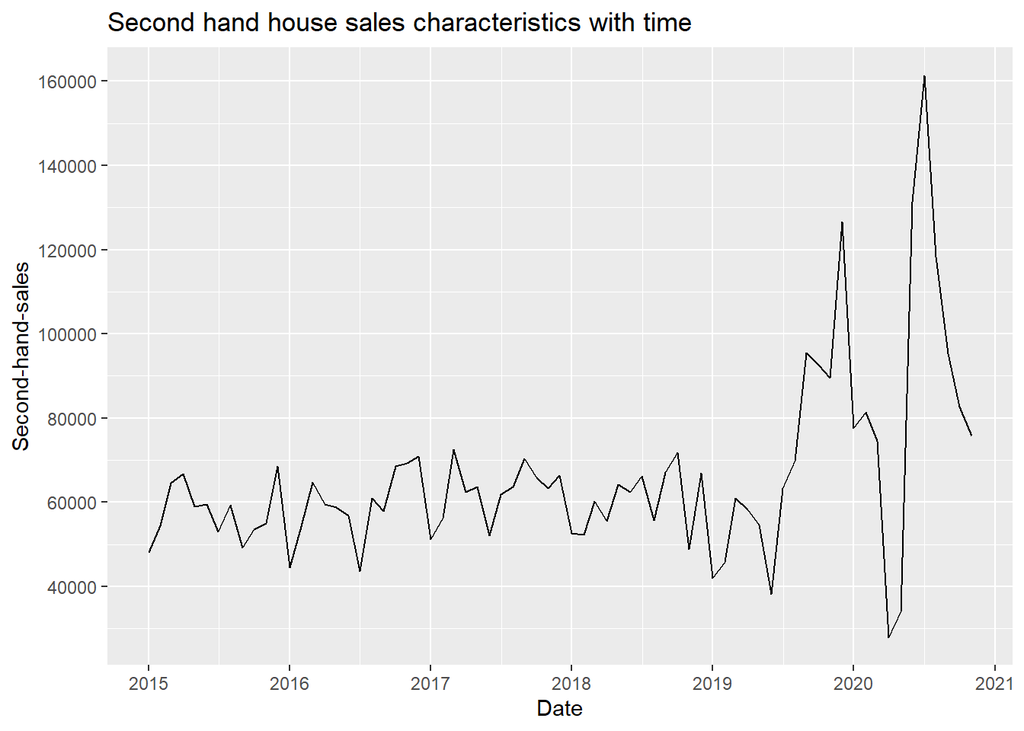

```r
ggplot(data=secondhandsales,aes(x=Date,group=1))+
  geom_line(aes(y=`Second-hand-sales`),)+
  scale_x_date(date_breaks="1 year", date_labels="%Y")+
  scale_y_continuous(breaks=seq(40000, 160000, by = 20000))+
  ggtitle("Second hand house sales characteristics with time")
```

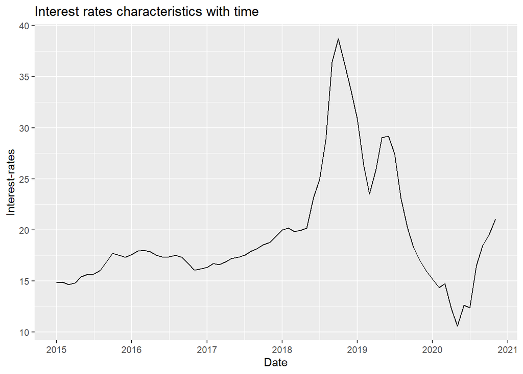

```r
ggplot(data=interestrates,aes(x=Date,group=1))+
  geom_line(aes(y=`Interest-rates`))+
  scale_x_date(date_breaks="1 year", date_labels="%Y")+
  scale_y_continuous(breaks=seq(10, 40, by = 5))+
  ggtitle("Interest rates characteristics with time")
```

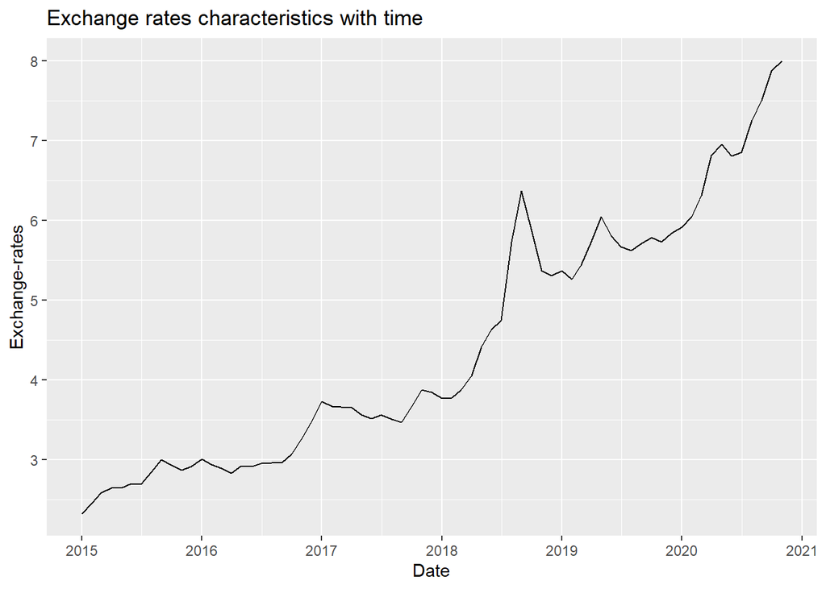

```r
ggplot(data=exchangerates,aes(x=Date,group=1))+
  geom_line(aes(y=`Exchange-rates`))+
  scale_x_date(date_breaks="1 year", date_labels="%Y")+
  scale_y_continuous(breaks=seq(3, 8, by = 1))+
  ggtitle("Exchange rates characteristics with time")
```

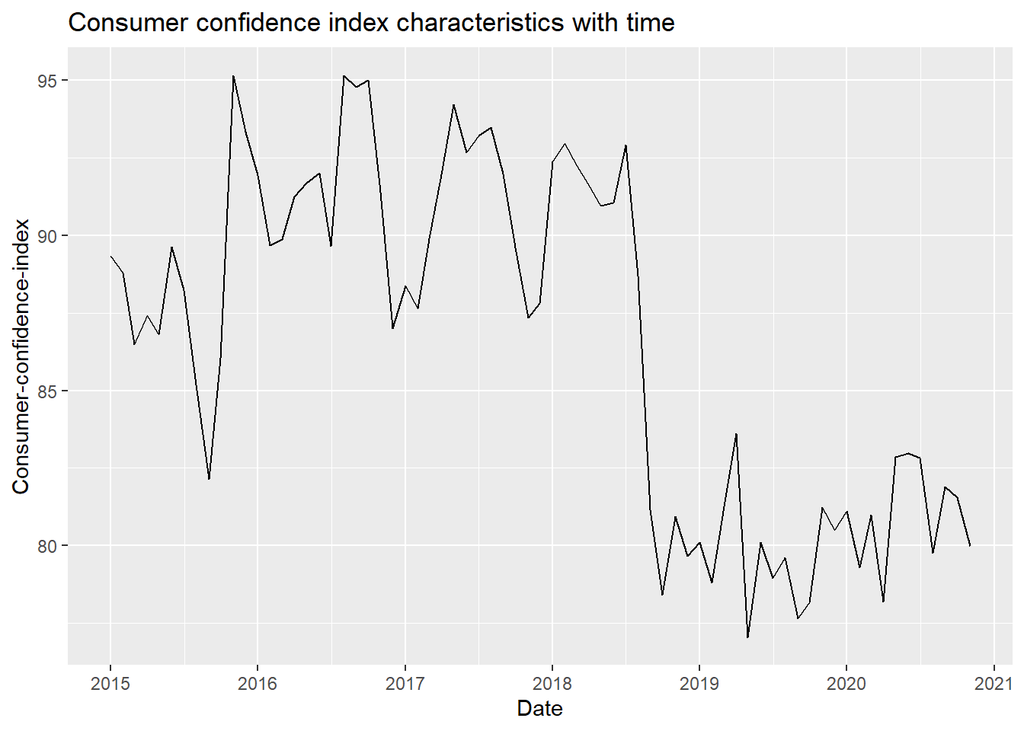

```r
ggplot(data=consumerconfidenceindex,aes(x=Date,group=1))+
  geom_line(aes(y=`Consumer-confidence-index`))+
  scale_x_date(date_breaks="1 year", date_labels="%Y")+
  scale_y_continuous(breaks=seq(75, 100, by = 5))+
  ggtitle("Consumer confidence index characteristics with time")
```

## Analysis

We build 3 models between second hand house sales and interest rates, exchange rates and consumer confidence index. Then we check their multiple R-squared values and p-values. From these summaries we see that exchange rates have better multiple R-squared value than other two. From this we may think exchange rates are a better modeling parameter. But we need to think about combinations of these or other parameters.

```r
fit_month<-lm (`Second-hand-sales`~`Interest-rates`,secondhandsales)
summary(fit_month)
```

```
##
## Call:
## lm(formula = `Second-hand-sales` ~ `Interest-rates`, data = secondhandsales)
##
## Residuals:
##    Min     1Q Median     3Q    Max
## -43111 -11933  -3295   4529  90356
##
## Coefficients:
##                  Estimate Std. Error t value Pr(>|t|)
## (Intercept)       80152.3     8904.8   9.001 2.97e-13 ***
## `Interest-rates`   -734.9      437.1  -1.681   0.0973 .
## ---
## Signif. codes:  0 '***' 0.001 '**' 0.01 '*' 0.05 '.' 0.1 ' ' 1
##
## Residual standard error: 21240 on 69 degrees of freedom
## Multiple R-squared:  0.03935,    Adjusted R-squared:  0.02542
## F-statistic: 2.826 on 1 and 69 DF,  p-value: 0.09726
```

```r
fit_month<-lm (`Second-hand-sales`~`Exchange-rates`,secondhandsales)
summary(fit_month)
```

```
##
## Call:
## lm(formula = `Second-hand-sales` ~ `Exchange-rates`, data = secondhandsales)
##
## Residuals:
##    Min     1Q Median     3Q    Max
## -52118  -8673  -1406   5372  81175
##
## Coefficients:
##                  Estimate Std. Error t value Pr(>|t|)
## (Intercept)         39271       7011   5.601 4.03e-07 ***
## `Exchange-rates`     5981       1492   4.008 0.000153 ***
## ---
## Signif. codes:  0 '***' 0.001 '**' 0.01 '*' 0.05 '.' 0.1 ' ' 1
##
## Residual standard error: 19510 on 69 degrees of freedom
## Multiple R-squared:  0.1889, Adjusted R-squared:  0.1771
## F-statistic: 16.06 on 1 and 69 DF,  p-value: 0.0001526
```

```r
fit_month<-lm (`Second-hand-sales`~`Consumer-confidence-index`,secondhandsales)
summary(fit_month)
```

```
##
## Call:
## lm(formula = `Second-hand-sales` ~ `Consumer-confidence-index`,
##     data = secondhandsales)
##
## Residuals:
##    Min     1Q Median     3Q    Max
## -46759  -8765  -1605   5719  91642
##
## Coefficients:
##                             Estimate Std. Error t value Pr(>|t|)
## (Intercept)                 157432.1    38878.4   4.049 0.000132 ***
## `Consumer-confidence-index`  -1058.3      448.1  -2.362 0.021013 *
## ---
## Signif. codes:  0 '***' 0.001 '**' 0.01 '*' 0.05 '.' 0.1 ' ' 1
##
## Residual standard error: 20840 on 69 degrees of freedom
## Multiple R-squared:  0.0748, Adjusted R-squared:  0.06139
## F-statistic: 5.578 on 1 and 69 DF,  p-value: 0.02101
```

We add other parameters trend, year and month to see if they have any effect on second hand house sales. As we predict from the plot of second hand house sales above we should eliminate the effect of covid-19 by appointing it to 1(months 64 and 65) for our model to see that value as a normal value. Then we add our selected 3 parameters interest rates, exchange rates and consumer confidence index to see which combination gives us the best solution among them.

```r
secondhandsales[,trend_comp:=1:.N]
secondhandsales[,Year:=year(Date)]
secondhandsales[,Month:=as.factor(month(Date))]
secondhandsales[64:65,remove_seasonality:=1]
secondhandsales[is.na(remove_seasonality)==T,remove_seasonality:=0]
secondhandsales
```

```
##           Date Second-hand-sales Interest-rates Exchange-rates
##  1: 2015-01-01             48196        14.8640       2.328343
##  2: 2015-02-01             54359        14.8900       2.455225
##  3: 2015-03-01             64543        14.6750       2.583841
##  4: 2015-04-01             66719        14.8375       2.648143
##  5: 2015-05-01             58887        15.4300       2.646137
##  6: 2015-06-01             59455        15.6750       2.701159
##  7: 2015-07-01             52966        15.7020       2.694605
##  8: 2015-08-01             59245        16.0450       2.845557
##  9: 2015-09-01             49150        16.9075       3.002715
## 10: 2015-10-01             53534        17.6980       2.929576
## 11: 2015-11-01             55032        17.5100       2.871286
## 12: 2015-12-01             68567        17.3300       2.917235
## 13: 2016-01-01             44479        17.6100       3.006950
## 14: 2016-02-01             54294        17.9425       2.940662
```

[output cut: 131 more lines]

```r
fit_month<-lm (`Second-hand-sales`~`Interest-rates`+trend_comp,secondhandsales)
summary(fit_month)
```

```
##
## Call:
## lm(formula = `Second-hand-sales` ~ `Interest-rates` + trend_comp,
##     data = secondhandsales)
##
## Residuals:
##    Min     1Q Median     3Q    Max
## -62484  -7532  -1700   6681  69296
##
## Coefficients:
##                  Estimate Std. Error t value Pr(>|t|)
## (Intercept)       70319.5     7863.8   8.942 4.29e-13 ***
## `Interest-rates`  -1259.7      388.1  -3.246  0.00182 **
## trend_comp          558.0      109.2   5.110 2.81e-06 ***
## ---
## Signif. codes:  0 '***' 0.001 '**' 0.01 '*' 0.05 '.' 0.1 ' ' 1
##
## Residual standard error: 18180 on 68 degrees of freedom
## Multiple R-squared:  0.3059, Adjusted R-squared:  0.2855
## F-statistic: 14.98 on 2 and 68 DF,  p-value: 4.06e-06
```

```r
fit_month<-lm (`Second-hand-sales`~`Exchange-rates`+trend_comp,secondhandsales)
summary(fit_month)
```

```
##
## Call:
## lm(formula = `Second-hand-sales` ~ `Exchange-rates` + trend_comp,
##     data = secondhandsales)
##
## Residuals:
##    Min     1Q Median     3Q    Max
## -51352  -8661   -337   6884  80998
##
## Coefficients:
##                  Estimate Std. Error t value Pr(>|t|)
## (Intercept)       46542.7    10448.9   4.454 3.22e-05 ***
## `Exchange-rates`   1390.2     5110.5   0.272    0.786
## trend_comp          363.5      387.0   0.939    0.351
## ---
## Signif. codes:  0 '***' 0.001 '**' 0.01 '*' 0.05 '.' 0.1 ' ' 1
##
## Residual standard error: 19530 on 68 degrees of freedom
## Multiple R-squared:  0.1992, Adjusted R-squared:  0.1757
## F-statistic:  8.46 on 2 and 68 DF,  p-value: 0.0005236
```

```r
fit_month<-lm (`Second-hand-sales`~`Consumer-confidence-index`+trend_comp,secondhandsales)
summary(fit_month)
```

```
##
## Call:
## lm(formula = `Second-hand-sales` ~ `Consumer-confidence-index` +
##     trend_comp, data = secondhandsales)
##
## Residuals:
##    Min     1Q Median     3Q    Max
## -50339  -8719   -820   7680  80966
##
## Coefficients:
##                             Estimate Std. Error t value Pr(>|t|)
## (Intercept)                  34934.7    52416.4   0.666  0.50736
## `Consumer-confidence-index`    152.1      561.2   0.271  0.78720
## trend_comp                     491.4      151.2   3.251  0.00179 **
## ---
## Signif. codes:  0 '***' 0.001 '**' 0.01 '*' 0.05 '.' 0.1 ' ' 1
##
## Residual standard error: 19530 on 68 degrees of freedom
## Multiple R-squared:  0.1992, Adjusted R-squared:  0.1757
## F-statistic: 8.459 on 2 and 68 DF,  p-value: 0.0005238
```

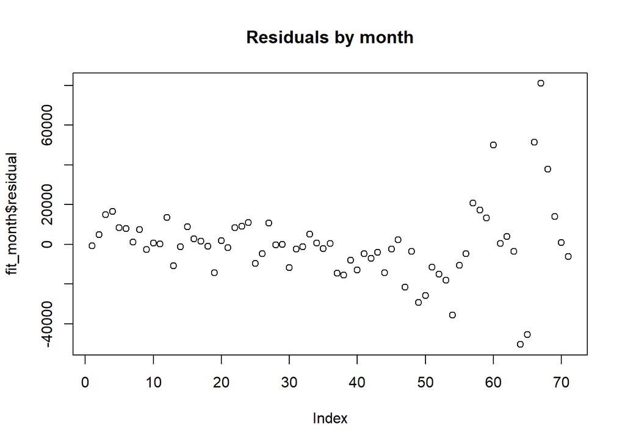

```r
plot(fit_month$residual,main="Residuals by month")
```

```r
fit_month<-lm (`Second-hand-sales`~`Interest-rates`+`Exchange-rates`+as.factor(Month)+Year+trend_comp+as.factor(remove_seasonality),secondhandsales)
summary(fit_month)
```

```
##
## Call:
## lm(formula = `Second-hand-sales` ~ `Interest-rates` + `Exchange-rates` +
##     as.factor(Month) + Year + trend_comp + as.factor(remove_seasonality),
##     data = secondhandsales)
##
## Residuals:
##    Min     1Q Median     3Q    Max
## -25349  -6477    501   4381  46100
##
## Coefficients: (1 not defined because of singularities)
##                                 Estimate Std. Error t value Pr(>|t|)
## (Intercept)                    -833813.9  6292289.7  -0.133  0.89506
## `Interest-rates`                 -2226.8      299.5  -7.434 7.34e-10 ***
## `Exchange-rates`                  9866.8     3565.0   2.768  0.00768 **
## as.factor(Month)2                 3091.9     7395.5   0.418  0.67751
## as.factor(Month)3                 9777.6     7415.7   1.318  0.19280
## as.factor(Month)4                10210.5     7618.2   1.340  0.18566
## as.factor(Month)5                10295.9     7672.9   1.342  0.18516
## as.factor(Month)6                10509.3     7512.0   1.399  0.16742
## as.factor(Month)7                18559.9     7522.3   2.467  0.01675 *
## as.factor(Month)8                14291.8     7717.3   1.852  0.06941 .
## as.factor(Month)9                16547.4     7917.9   2.090  0.04127 *
## as.factor(Month)10               16980.7     7952.0   2.135  0.03720 *
## as.factor(Month)11               10419.0     7940.7   1.312  0.19494
## as.factor(Month)12               27897.9     8123.8   3.434  0.00114 **
## Year                               440.8     3125.3   0.141  0.88834
## trend_comp                            NA         NA      NA       NA
## as.factor(remove_seasonality)1  -78279.4    11092.5  -7.057 3.04e-09 ***
## ---
## Signif. codes:  0 '***' 0.001 '**' 0.01 '*' 0.05 '.' 0.1 ' ' 1
##
## Residual standard error: 12800 on 55 degrees of freedom
## Multiple R-squared:  0.7216, Adjusted R-squared:  0.6457
## F-statistic: 9.506 on 15 and 55 DF,  p-value: 1.925e-10
```

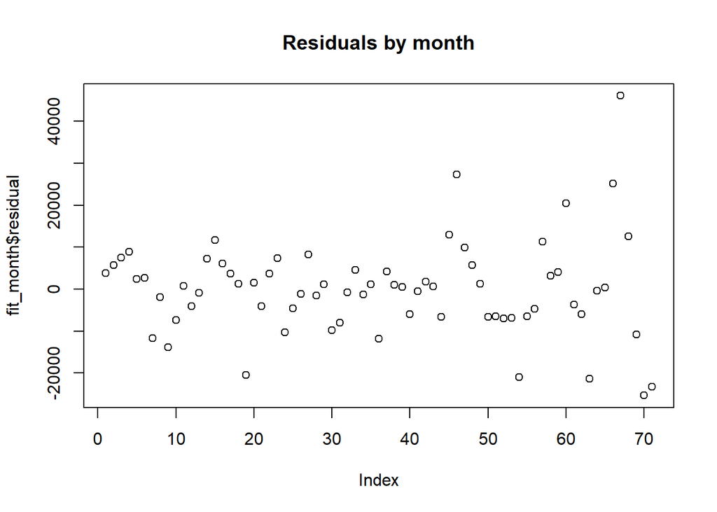

```r
plot(fit_month$residual,main="Residuals by month")
```

```r
fit_month<-lm (`Second-hand-sales`~`Exchange-rates`+trend_comp+Month+Year,secondhandsales)
summary(fit_month)
```

```
##
## Call:
## lm(formula = `Second-hand-sales` ~ `Exchange-rates` + trend_comp +
##     Month + Year, data = secondhandsales)
##
## Residuals:
##    Min     1Q Median     3Q    Max
## -40679  -9446  -1576   9055  73111
##
## Coefficients: (1 not defined because of singularities)
##                  Estimate Std. Error t value Pr(>|t|)
## (Intercept)       36536.9    12868.7   2.839  0.00626 **
## `Exchange-rates`   1505.2     5262.7   0.286  0.77591
## trend_comp          324.8      395.6   0.821  0.41508
## Month2             4411.0    11323.2   0.390  0.69832
## Month3            12794.4    11320.8   1.130  0.26314
## Month4             1027.6    11325.6   0.091  0.92802
## Month5             1126.1    11342.6   0.099  0.92126
## Month6            11860.8    11331.8   1.047  0.29966
## Month7            19700.5    11339.7   1.737  0.08774 .
## Month8            15431.1    11365.8   1.358  0.17992
## Month9            16077.5    11423.7   1.407  0.16474
## Month10           15647.1    11409.7   1.371  0.17563
## Month11            9789.3    11390.6   0.859  0.39371
## Month12           25205.3    11895.2   2.119  0.03847 *
## Year                   NA         NA      NA       NA
## ---
## Signif. codes:  0 '***' 0.001 '**' 0.01 '*' 0.05 '.' 0.1 ' ' 1
##
## Residual standard error: 19600 on 57 degrees of freedom
## Multiple R-squared:  0.3239, Adjusted R-squared:  0.1697
## F-statistic:   2.1 on 13 and 57 DF,  p-value: 0.02807
```

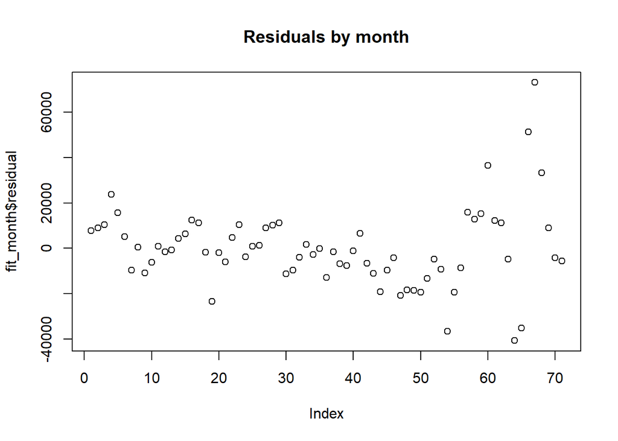

```r
plot(fit_month$residual,main="Residuals by month")
```

```r
fit_month<-lm (`Second-hand-sales`~`Consumer-confidence-index`+trend_comp+Month+Year,secondhandsales)
summary(fit_month)
```

```
##
## Call:
## lm(formula = `Second-hand-sales` ~ `Consumer-confidence-index` +
##     trend_comp + Month + Year, data = secondhandsales)
##
## Residuals:
##    Min     1Q Median     3Q    Max
## -39395  -8632  -2355   9338  73422
##
## Coefficients: (1 not defined because of singularities)
##                             Estimate Std. Error t value Pr(>|t|)
## (Intercept)                  21458.4    54203.1   0.396   0.6937
## `Consumer-confidence-index`    191.6      576.6   0.332   0.7409
## trend_comp                     467.4      154.4   3.027   0.0037 **
## Month2                        4469.8    11325.1   0.395   0.6946
## Month3                       12757.6    11316.5   1.127   0.2643
## Month4                         980.4    11325.8   0.087   0.9313
## Month5                        1154.8    11331.9   0.102   0.9192
## Month6                       11549.7    11373.6   1.015   0.3142
## Month7                       19355.6    11367.5   1.703   0.0941 .
## Month8                       15429.2    11358.0   1.358   0.1797
## Month9                       16599.4    11361.7   1.461   0.1495
## Month10                      16093.3    11370.6   1.415   0.1624
## Month11                       9846.7    11377.2   0.865   0.3904
## Month12                      25178.2    11886.2   2.118   0.0385 *
## Year                              NA         NA      NA       NA
## ---
## Signif. codes:  0 '***' 0.001 '**' 0.01 '*' 0.05 '.' 0.1 ' ' 1
##
## Residual standard error: 19600 on 57 degrees of freedom
## Multiple R-squared:  0.3242, Adjusted R-squared:  0.1701
## F-statistic: 2.104 on 13 and 57 DF,  p-value: 0.02781
```

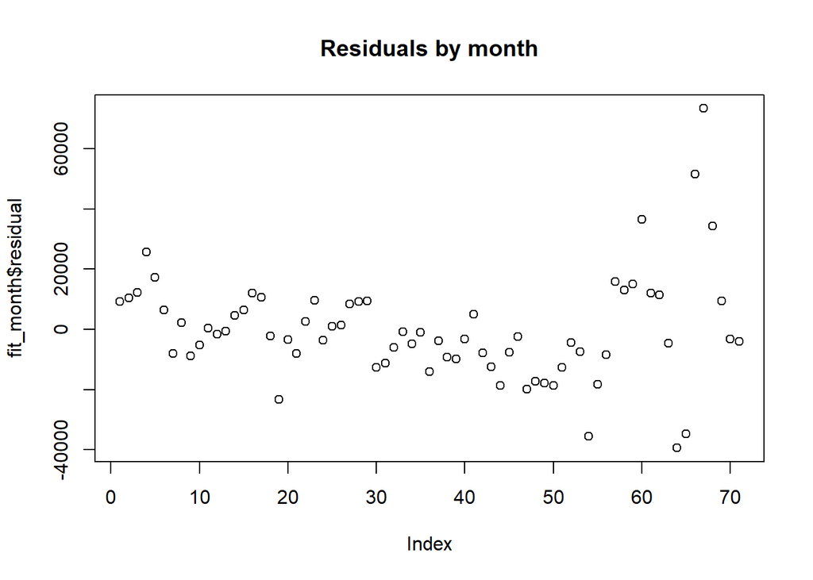

```r
plot(fit_month$residual,main="Residuals by month")
```

We look at the auto correlation function of second hand house sales and cross correlation function of second hand house sales with other 3 components. Then we plot the relationship between them. Next we plot second hand house sales and residuals.

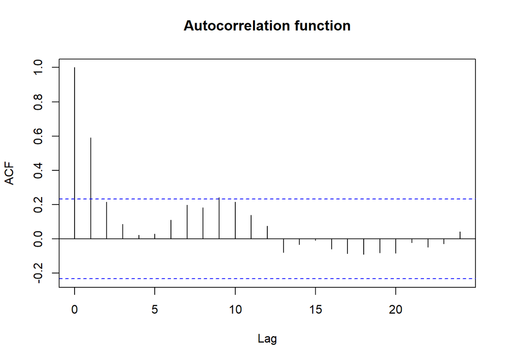

```r
acf(secondhandsales[,2],lag.max = 24,main="Autocorrelation function")
```

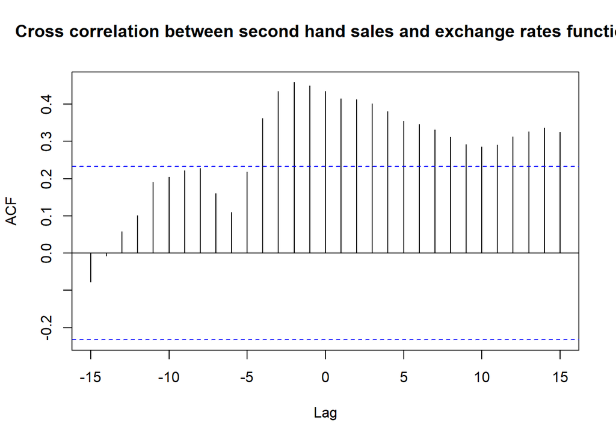

```r
ccf(secondhandsales$`Second-hand-sales`,secondhandsales$`Exchange-rates`,main="Cross correlation between second hand sales and exchange rates function")
```

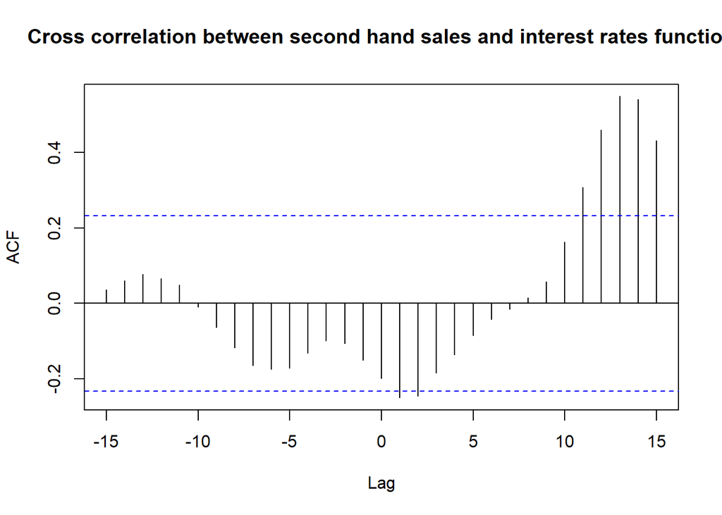

```r
ccf(secondhandsales$`Second-hand-sales`,secondhandsales$`Interest-rates`,main="Cross correlation between second hand sales and interest rates function")
```

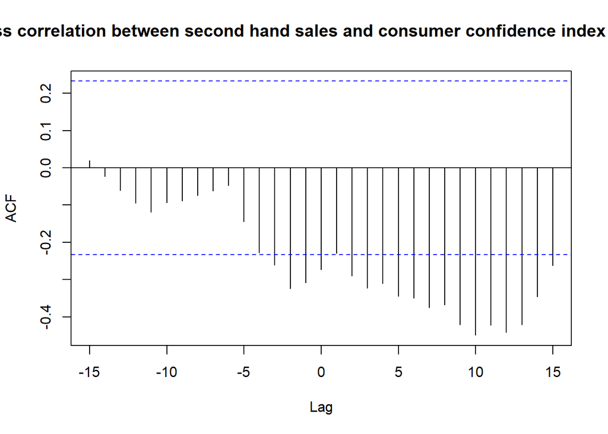

```r
ccf(secondhandsales$`Second-hand-sales`,secondhandsales$`Consumer-confidence-index`,main="Cross correlation between second hand sales and consumer confidence index function")
```

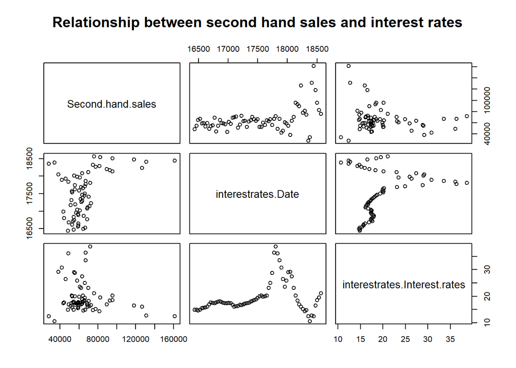

```r
plot(secondhandsales[,list(`Second-hand-sales`,interestrates)],main="Relationship between second hand sales and interest rates")
```

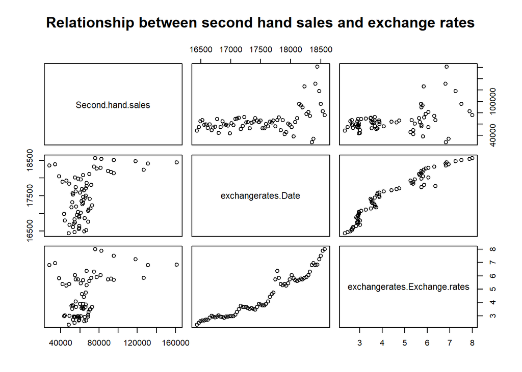

```r
plot(secondhandsales[,list(`Second-hand-sales`,exchangerates)],main="Relationship between second hand sales and exchange rates")
```

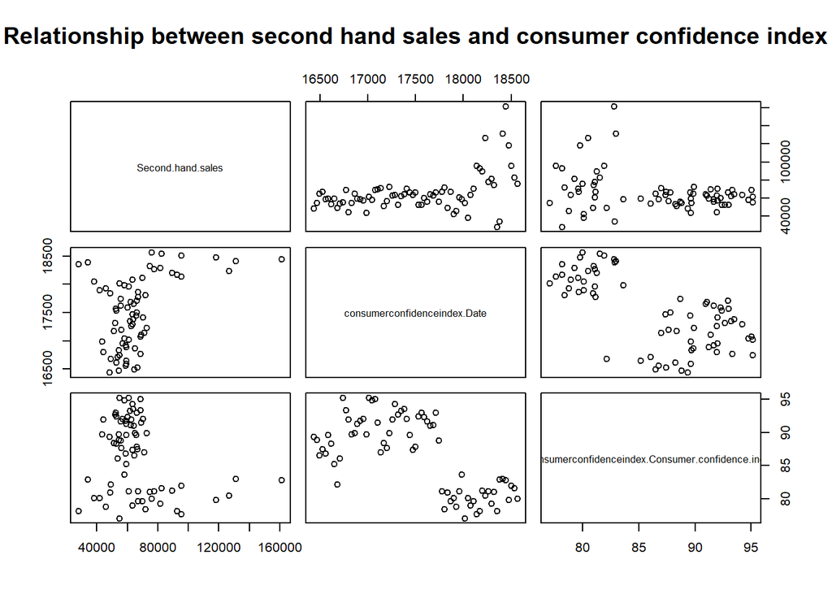

```r
plot(secondhandsales[,list(`Second-hand-sales`,consumerconfidenceindex)],main="Relationship between second hand sales and consumer confidence index")
```

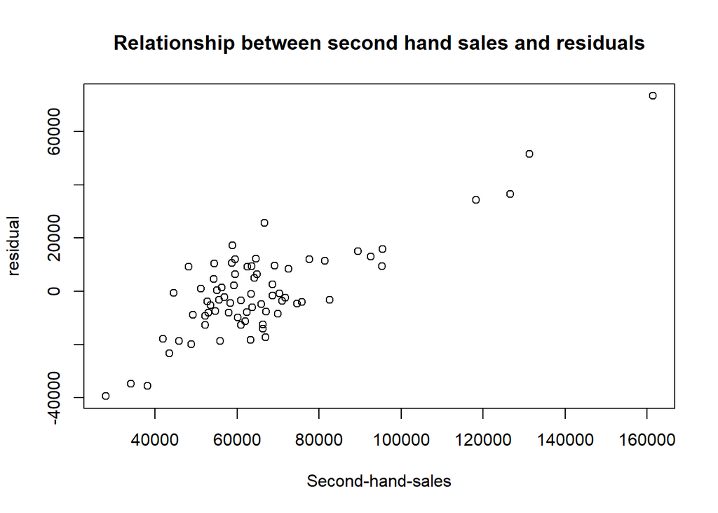

```r
plot(secondhandsales[,list(`Second-hand-sales`,residual=fit_month$residual)],main="Relationship between second hand sales and residuals")
```

```r
secondhandsales[,fitted:=fitted(fit_month)]
secondhandsales[,residual:=residuals(fit_month)]

nextmonth<-"2020-12-01"
secondhandsales<-rbind(secondhandsales,data.table(Date=as.Date(nextmonth)),fill = T)

secondhandsales[.N,remove_seasonality:=0]
secondhandsales[.N,trend_comp:=72]
secondhandsales[.N,Month:=12]
secondhandsales[.N,Year:=2020]
secondhandsales[.N,`Interest-rates`:=secondhandsales[.N-1,`Interest-rates`]]
secondhandsales[.N,`Exchange-rates`:=secondhandsales[.N-1,`Exchange-rates`]]
secondhandsales[.N,`Consumer-confidence-index`:=secondhandsales[.N-1,`Consumer-confidence-index`]]

predict(fit_month,secondhandsales[is.na(fitted)==T])
```

```
##        1
## 95613.14
```

```r
secondhandsales[is.na(fitted)==T,fitted:=predict(fit_month,secondhandsales[is.na(fitted)==T])]
```

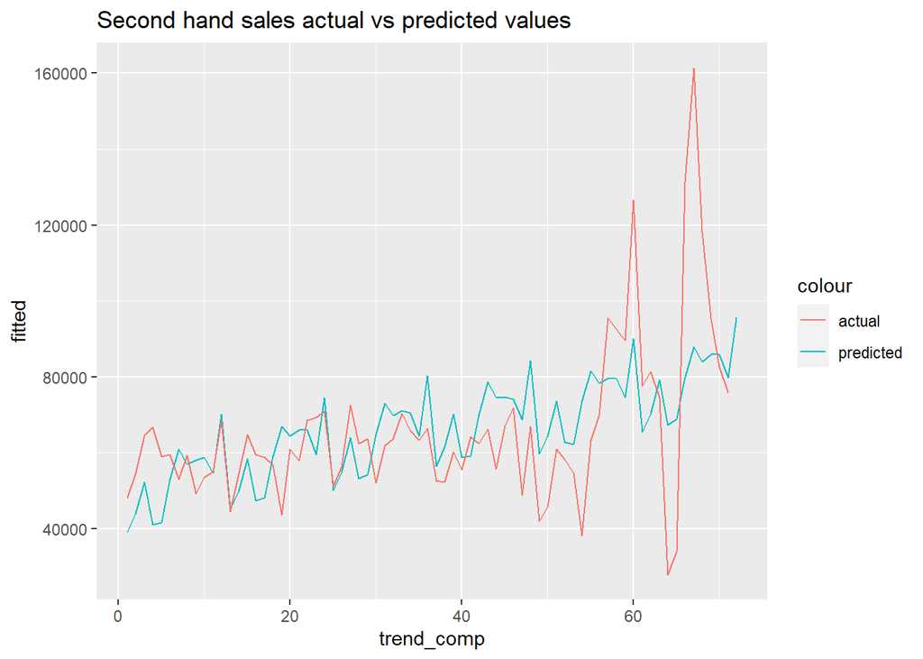

```r
cols<-c("predicted" = "orange", "actual" = "black")
ggplot() +
  geom_line(data=secondhandsales,aes(x =trend_comp,y =fitted,color="predicted")) +
  geom_line(data=secondhandsales,aes(x =trend_comp,y=`Second-hand-sales`,color="actual")) +
  labs(xlab='Date(months)',ylab='Second hand sales', title='Second hand sales actual vs predicted values')
```

```r
  scale_color_manual(values=cols)
```

[output not shown]

```r
tail(secondhandsales)
```

```
##          Date Second-hand-sales Interest-rates Exchange-rates
## 1: 2020-07-01            161420        12.3680       6.851095
## 2: 2020-08-01            118285        16.5350       7.252190
## 3: 2020-09-01             95368        18.4825       7.507782
## 4: 2020-10-01             82598        19.5020       7.873881
## 5: 2020-11-01             75825        21.0825       8.003324
## 6: 2020-12-01                NA        21.0825       8.003324
##    Consumer-confidence-index trend_comp Year Month remove_seasonality   fitted
## 1:                  82.82247         67 2020     7                  0 87997.57
## 2:                  79.77182         68 2020     8                  0 83954.02
## 3:                  81.90816         69 2020     9                  0 86000.94
## 4:                  81.54335         70 2020    10                  0 85892.25
## 5:                  79.98411         71 2020    11                  0 79814.28
## 6:                  79.98411         72 2020    12                  0 95613.14
##     residual
## 1: 73422.431
## 2: 34330.984
## 3:  9367.064
## 4: -3294.255
## 5: -3989.278
## 6:        NA
```